# The fiscal and external accounts of the LEEDS model

The current account omitted the net cross-border tariff settlement, which is the whole of the balance-of-payments residual and is now fixed on branch bop-audit; and the model’s only economic instability is one unrecycled interest flow from the Rest of the World’s treasury to the EU central bank

Author

LEEDS_MODEL — JUST2CE

Published

September 11, 2026

**Written:** 2026-09-11 · **Repo at:** branch `bop-audit` @ `865749e` (branched from `main` @ `b44cf42`)

**Read from:** `model/MVP_model_2026.R` (the equations; lines cited as `:NNN` refer to this file on `bop-audit`, where the new current-account term sits at `:804–813` and every line after it is shifted by 11 relative to `main`) · `output/scenarios/full_mrio_baseline_2026.RDS` (the canonical baseline, bit-identical to the `submitted` tariff-arm baseline) · `output/scenarios/shock_runs/shock_{5,7,13}_run.RDS` · `output/scenarios/arms/{submitted,customs}/runs/` (the tariff-arm baselines and shock runs) · `data/transition_matrix_t50.rds` (the linearised one-period transition matrix) · `R/bop_audit.R` and `R/bop_fix_check.R` (**written for this report**, commit `865749e`) · `log/NEXT_SESSION.md` (hand-off item 1) · `log/session_20260909.md` §12–13 and `log/report/2026-09-09-transition-matrix-spectrum.qmd` (the spectrum) · `log/report/2026-09-09-tax-wedge-stage.qmd` (the tariff conventions) · `qmd/paper_revision_2026-11-13.qmd:612, :623, :705` (the current-account claims in the revision).

**Status of claims:** every number in a table or inline below is recomputed from the cached runs when this document is rendered, except the verification of the fixed model (§ “The fix”), which quotes the output of `R/bop_fix_check.R` because the fixed runs live outside the repository. Derivations from the source are labelled as such. Anything not verified is marked ⚠️ UNCERTAIN.

## What this is about

The object is the pair of accounts that close the LEEDS model’s two regions against each other: each government’s budget and debt, and each region’s balance of payments. Two questions were open. The first came from the project’s close-out plan (`ai_context/plans/2026-09-10-close-out.md`, Task 5, “the gate”): the EU runs a current-account surplus that its measured stock of foreign assets does not match, and about 60% of the surplus had no identified counterpart. The second came from the maintainer: the linearised model has two explosive eigenvalues, equal to one plus each region’s bill rate, and the question was what that instability *is* in economic terms — who is indebted to whom, who would have to contract, what would let the economy grow, and whether different closures are needed.

Both are answered here, and the answers turn out to be connected through the same variables. **The balance-of-payments residual is located exactly:** the coded current account omitted the net cross-border settlement of tariffs, and that omission is the whole of the residual in every period, under every tariff specification. With one term added, the balance of payments closes. **The debt instability is located exactly too:** it is one flow — interest that the Rest of the World’s treasury pays to the EU central bank on its reserve holdings, borrowed from that same central bank — and it involves no private income, wealth or spending variable at all, which is why nothing in the model acts to stop it compounding.

## Background the reader may not have

### Project shorthand

- **`Z1`** is the European Union, **`Z2`** the Rest of the World (RoW). Variables are prefixed by region.
- **`cab`** current-account balance; **`tb`** trade balance; **`kabp`** financial account net of official transactions (net private capital inflow); **`nafa`** net accumulation of financial assets, coded as `gdef + cab`.
- **`gdef`** government deficit including interest; **`b_s`** government bills outstanding; **`b_cb`** a central bank’s holdings of its own government’s bills; **`Z1_b_cb_s_Z2`** the EU central bank’s holdings of RoW bills — its foreign reserves; **`rb`** the bill rate.
- **`yn`** net national income (`:215–223`), from which firm profits are computed; **`tar_rev`** a government’s tariff revenue.
- **`va`** value added as the model defines it; it is the denominator of the model’s `debt_gdp`, and “% of VA” below means a share of it.
- **Tariff arms.** Three specifications of the tariff revenue base, selected by `options(leeds.tar_spec = ...)` at `:428`: `submitted` (the published line, a real import volume times the tariff rate), `author_variant`, and `customs` (the pre-VAT foreign price, the destination principle). The canonical cached runs are `submitted`.
- **Timing.** 100 periods; shocks switch on at `t.shock` = 70; Table 3 of the manuscript reports percentage deviations at t = 90 (“LT”, t.shock + 20).
- **Units.** Model currency units. Prices are frozen over the run (the mean EU price index is 1.074 at every period measured), so nominal and real magnitudes move together.

### The balance-of-payments identity, and how this model settles it

For each region the balance of payments must satisfy $\text{current account} + \text{net private capital inflow} = \text{net accumulation of official reserve assets}$, i.e. `cab + kabp = official settlement`. The residual of that identity is what the audit measures.

The model’s official settlement comes from its **fixed-exchange-rate closure** (`:853–866`, following Godley and Lavoie 2007, equations 12.89F–12.91F). The exchange rate `xr` is held at 1. In place of a price adjustment, the EU central bank is made the **residual buyer of RoW bills**: `Z1_b_cb_s_Z2` is whatever part of the RoW’s bill supply RoW households, RoW banks, the RoW central bank and EU households do not demand (`:859`). The source comments that “Z1 has World Money” (`:483`). The RoW has no reserve asset of its own, so the two regions’ closures are not mirror images: EU reserve accumulation is the RoW’s official borrowing. Gold (`or`) exists in the code but is zero throughout.

### Why a change to a reporting variable can move other variables slightly

Each period is solved by Gauss–Seidel iteration — the equations are re-evaluated in sequence until successive iterates stop changing. The shipped stopping rule (`model/run_model_2026.R`) stops when **every one** of the 6,713 variables’ relative change is below 10⁻⁶, reporting variables included. Changing a variable that feeds nothing else can therefore still change the sweep at which a period stops, and so move every other variable by amounts of the order of the solver tolerance. This matters for reading the verification of the fix below.

### The transition matrix

`log/report/2026-09-09-transition-matrix-spectrum.qmd` formed the model’s linearised one-period map $ds_t = M\,ds_{t-1}$ as an explicit 588 × 588 matrix and found its spectral radius $\rho(M) = 1.02167$, with exactly two eigenvalues outside the unit circle, equal to $1 + r_b$ for each region. This report reads the **eigenvectors** of those two roots, which that report tabulated only by variable block. Because the two eigenvalues are distinct, their eigenvectors are identified (unlike the 105 unit roots, whose eigenvectors are an arbitrary basis of a shared subspace).

## The object: the baseline’s real, fiscal and external accounts

### The real economy is stationary

Per-period growth rates on the canonical baseline, per cent.

| Region | Variable | t = 50 | t = 70 | t = 99 |
| --- | --- | --- | --- | --- |
| Z1 | gross output value | 0.0652 | 0.0072 | -0.0013 |
| Z1 | value added | 0.0611 | 0.0066 | -0.0013 |
| Z1 | real consumption | 0.0648 | 0.0052 | -0.0023 |
| Z1 | private investment | 0.1172 | 0.0156 | -0.0009 |
| Z1 | household wealth | 0.1089 | 0.0092 | -0.0033 |
| Z1 | private capital stock | 0.1590 | 0.0223 | -0.0006 |
| Z2 | gross output value | 0.0836 | 0.0113 | -0.0008 |
| Z2 | value added | 0.0804 | 0.0108 | -0.0008 |
| Z2 | real consumption | 0.0856 | 0.0105 | -0.0014 |
| Z2 | private investment | 0.1543 | 0.0235 | -0.0000 |
| Z2 | household wealth | 0.1370 | 0.0174 | -0.0016 |
| Z2 | private capital stock | 0.1923 | 0.0300 | 0.0004 |

**Observed.** Growth decays towards zero: by t = 99 every aggregate moves by less than 0.004% per period. The baseline is a **stationary state** in the Godley–Lavoie sense, not a contraction. Contraction in this model exists only as a scenario’s deviation from this flat path.

**Why it is stationary — read from the source and the calibration.** Nothing autonomous grows:

The components of demand and supply, and why none of them grows.

| Component | Equation | As calibrated |
| --- | --- | --- |
| Government consumption | `:357` | g = g₋₁(1 + g_g) + g0, with g_g = 0, g0 = 0 |
| Government investment | `:364` | id_g = da_g + id0: id0 = 50 (Z1), 230 (Z2); δ_g = 0 |
| Private investment | `:272` | γ(kt − k₋₁) + da + id_p0: target capital proportional to output, γ = 0.15, id_p0 = 0 |
| Consumption | `:86` | α₁ = 0.8544 on wage income, α₂ = 0.4191 on capital income, α₃ = 0.0994 on wealth |
| Exports | `:772`, `:775` | each region's exports are the other region's imports |
| Productivity, wages, prices | `:606`, `:616` | constant at t = 10, 50, 76 and 99 (mean EU productivity 0.235894) |
| Population | `:884–891` | set equal to employment until t = 75, flat afterwards; output equals potential by construction |

In supermultiplier terms — long-run output is autonomous demand times the supermultiplier, and the long-run growth rate equals the growth rate of autonomous demand — autonomous demand here is government consumption and investment, both flat, so the growth rate is zero. The supply side is passive: potential output is productivity times a population defined as employment.

### The fiscal accounts: both governments already run primary surpluses

Government accounts at t = 99, as % of value added unless stated. Spending is consumption plus investment at their own price indices; revenue is income tax plus VAT plus tariffs; interest is the bill rate at t−1 on bills outstanding at t−1. The central bank's profit is remitted to its treasury (`:481–483`).

| Region | Spending | Revenue | Primary surplus | Gross interest | Own central bank's profit | Deficit incl. interest | Debt / VA | Debt growth per period |
| --- | --- | --- | --- | --- | --- | --- | --- | --- |
| Z1 | 25.68% | 28.01% | 2.32% | 1.91% | 0.12% | -6.601 | 0.886 | -0.602% |
| Z2 | 21.44% | 23.69% | 2.26% | 2.52% | 0.13% | 6.396 | 1.163 | 0.120% |

**Observed.** Each government runs a primary surplus of about 2.3% of value added. In a stationary economy with a bill rate of 2.159% (EU) and 2.167% (RoW), a constant debt stock requires a primary surplus equal to the net interest bill. That is the permanent transfer from taxpayers to bondholders that $r > g$ implies, and the model has already reached it through its automatic stabilisers: tax revenue responds to income, and interest paid to domestic holders returns as household income (bank profits `f_b` and deposit interest, `:95–131`), which is taxed and partly spent.

The EU central bank’s profit is small and net of two opposing parts: it earns 6.638 of interest on its RoW reserves and pays interest on a *short* position in its own government’s bills — `Z1_b_cb` has been negative since t = 29 and stands at -244.19 at t = 99. The model has no sterilisation instrument, so a central bank that buys foreign bills beyond its domestic bill holdings shows the difference as negative holdings.

### Who holds the bills

Holdings of each region's bills on the baseline.

| Stock | t = 70 | t = 99 | Change 70 → 99 |
| --- | --- | --- | --- |
| RoW bills outstanding | 5,191.70 | 5,334.81 | 143.115 |
| held by RoW households | 810.52 | 811.32 | 0.804 |
| held by RoW banks | 3,882.70 | 3,881.98 | -0.713 |
| held by RoW central bank | 265.40 | 265.57 | 0.166 |
| held by EU households | 63.15 | 63.14 | -0.008 |
| held by EU central bank (reserves) | 169.93 | 312.80 | 142.866 |
| EU bills outstanding | 1,233.41 | 1,089.22 | -144.188 |
| held by EU households | 210.50 | 210.47 | -0.027 |
| held by RoW households | 81.05 | 81.13 | 0.080 |
| held by EU banks | 1,043.18 | 1,041.81 | -1.368 |
| held by EU central bank | -101.32 | -244.19 | -142.873 |

**Observed.** Over the last thirty periods the RoW’s new debt is bought almost entirely by the EU central bank: 142.87 of 143.11. Every private holder is essentially constant. Why is read from the source: household bill demand is a fixed share of wealth (`Z1_b_h_Z1 = λ₁₀·v`, `:521–559`, with λ₁₀ = 0.1 and every rate-of-return coefficient zero), and wealth is stationary; banks hold bills as the residual of deposits over loans (`:335–345`); the RoW central bank’s holdings are its cash liabilities minus advances (`:849–851`). No agent except the EU central bank has a demand for bills that responds to the quantity supplied.

## What was found

### 1. The explosive root is one official-sector interest circuit

The two eigenvalues of M outside the unit circle at t = 50, with the five largest loadings of each eigenvector in absolute units. Every loading not shown is below 1e-6 in absolute value.

| Eigenvalue | Variable | Loading (absolute units, largest = 1) |
| --- | --- | --- |
| 1.021673047 | Z1_b_cb_s_Z2 | +1.000000 |
| 1.021673047 | Z2_b_s | +1.000000 |
| 1.021673047 | Z1_b_cb | -1.000000 |
| 1.021673047 | Z1_b_s | -0.999998 |
| 1.021673047 | ken | +0.000000 |
| 1.021591264 | Z1_b_s | +1.000000 |
| 1.021591264 | ken | +0.000000 |
| 1.021591264 | kmat | +0.000000 |
| 1.021591264 | res_en | +0.000000 |
| 1.021591264 | res_mat | +0.000000 |

**Observed.** The eigenvector of $\lambda_1 = 1 + r_b^{Z2}$ has four non-zero entries of equal magnitude: RoW bills outstanding (+1), EU central-bank reserves of RoW bills (+1), the EU central bank’s holdings of EU bills (−1), and EU bills outstanding (−1). **No private income, wealth, spending or real variable appears in it.**

**Observed, on the path itself.** The baseline’s stock drift from t = 70 to t = 99 *is* this eigenvector — the holder table above shows RoW bills +143, EU reserves +143, EU central-bank EU bills −143, EU bills −144.

**The mechanism, read from the source and checked against the budgets.** One period of the mode:

1. The RoW treasury owes interest on the RoW bills the EU central bank holds (`:454` on the RoW side). That interest is not paid to any RoW household, so it is neither taxed nor spent in the RoW; it raises the RoW deficit one for one.
2. The RoW finances the deficit by issuing bills, which the EU central bank buys as residual holder (`:859`). The interest is, in effect, borrowed from the creditor.
3. The EU central bank pays for the bills by running down its EU-bill portfolio (its balance-sheet equation, `:842–846`), and remits the RoW interest to the EU treasury as profit (`:482–483`).
4. The EU treasury does not spend it — government spending is exogenous — so its deficit falls and it retires EU bills, the ones its own central bank has just sold.

Both budgets are almost exactly balanced once that single flow is removed:

Government deficits with and without the reserve-interest flow. A negative deficit is a surplus.

| t | Reserve interest, RoW → EU central bank | EU deficit | EU deficit + reserve interest | RoW deficit | RoW deficit − reserve interest | Change in EU reserves |
| --- | --- | --- | --- | --- | --- | --- |
| 30 | 1.410 | 7.208 | 8.618 | 37.287 | 35.878 | 2.142 |
| 50 | 2.354 | -1.227 | 1.127 | 7.564 | 5.210 | 2.416 |
| 70 | 3.606 | -3.489 | 0.117 | 4.015 | 0.408 | 3.532 |
| 90 | 5.490 | -5.456 | 0.034 | 5.286 | -0.204 | 5.392 |
| 99 | 6.638 | -6.601 | 0.037 | 6.396 | -0.242 | 6.537 |

**Observed.** By t = 99 the EU budget net of reserve income is 0.037 and the RoW budget net of reserve interest -0.242, against a flow of 6.638. EU reserves grow by 6.537 per period, essentially the interest capitalised: the reserve stock compounds at the RoW bill rate.

**Inferred.** Because the mode touches no private variable, none of the model’s stabilising channels can act on it: taxes respond to income, consumption to income and wealth, and portfolio demands to wealth, and the circuit changes none of those. In a closed Godley–Lavoie economy the government’s own central bank is the residual bill holder and remits the interest to the same treasury, so debt held there does not compound (a root of 1, not $1 + r$). Here the residual holder is the *other* region’s central bank, whose treasury does not spend what it receives.

### 2. The second root is an accounting-residue direction, not an economic mode

**Observed.** The eigenvector of $\lambda_2 = 1 + r_b^{Z1}$ loads on EU bills outstanding alone (table in §1): a change in the supply of EU bills that no holder takes up. On any consistent path that direction is excluded, because EU bills must equal the sum of their holders — the model’s “hidden” redundant equation (commented at `:892`), which the model’s own consistency check (`:919–922`) measures. Along the baseline the violation is 1.769e-03 at t = 99, 1.62e-06 of the EU bill stock; half its square is 1.5645e-06, and the stored `consistency.error` at t = 99 is 1.5645e-06.

**Interpretation.** The EU bill supply is set by the deficit (`:461`) and each holding by its own equation, so the identity holds on the path only as a consequence of the whole system’s accounting. A perturbation that breaks it pays interest on bills held by nobody, and that interest compounds at the EU bill rate with no feedback. It is a property of the linearisation off the consistency manifold, not a dynamic the economy can follow.

### 3. How scenario deviations inherit the root

Fiscal deviations from baseline, levels in model units, for the two scenarios with the largest regional divergence. Net interest is interest paid minus own central-bank profit.

[output not shown]

**Observed.** In the divergence scenarios the RoW loses output, its tax take falls while spending is fixed, a primary deficit opens, and the debt it creates then earns interest at the RoW bill rate. By t = 99 about a quarter of the RoW’s accumulated debt deviation is interest on earlier deviation, and more than a third of that period’s deficit deviation; the EU mirrors it with surpluses. The share rises with the horizon because the interest term compounds while the primary term does not. **Consequence for reading the paper:** every `gdef` and `b_s` deviation mixes a stationary primary effect with a compound-interest term whose size depends on how long after the shock it is read.

### 4. The balance-of-payments residual is the net tariff settlement

**The derivation, from the source.** Take the private sector’s net lending — household saving `yd − c·pa` plus firm net lending `f_f_u + af − id·pid` — and substitute disposable income (`:95–131`), bank profit (`:348`), firm profit (`:226`) and net national income (`:215–223`). Interest and dividend terms cancel against the government budget (`:451–458`) and the coded current account (`:781–802`), and what is left is

$$\text{PNL} \;=\; gdef \;+\; cab_{\text{coded}} \;+\; tar\_rev^{\text{own}} \;-\; xr^{\text{partner}}\, tar\_rev^{\text{partner}} .$$

The reason is two lines that disagree about whose tariff falls on whom. **`yn` (`:223`) deducts the partner’s tariff revenue** from domestic income — the model treats a tariff as borne by the exporting region’s firms. **`gdef` (`:457`) credits the region’s own tariff revenue.** So each period the EU private sector pays the RoW’s tariff to the RoW government, and the EU government receives the EU tariff paid by RoW exporters. Those are cross-border payments, and the coded current account has no line for them. The trade balance `nex − nimp` cancels between regions by construction (`:775`: one region’s exports are the other’s imports), so the identity holds whatever the import price index (`:646`) contains and whatever tariff base the arm selects.

**The measurement.** `R/bop_audit.R` rebuilds the current account term by term (the rebuild matches the stored `cab` to 0 in every period), rebuilds the private capital flows from the stocks (to 6 × 10⁻⁸), and computes the residual.

EU balance-of-payments audit on two tariff-arm baselines. Residual = cab + kabp − official settlement. Net tariff settlement = own tariff revenue − partner's. The last column recomputes the residual from the income side. The RoW is the exact mirror (Z2 cab = −Z1 cab).

| Arm | t | cab as coded | Official settlement | kabp | Residual | Share of cab | Net tariff settlement | Residual + settlement | cab − national net lending |
| --- | --- | --- | --- | --- | --- | --- | --- | --- | --- |
| submitted | 3 | 6.0091 | 2.6656 | 2.69481 | 6.0383 | 100.5% | -6.0383 | 2.3e-05 | 6.0383 |
| submitted | 10 | 9.5315 | 3.8082 | 2.36038 | 8.0836 | 84.8% | -8.0836 | 7.1e-06 | 8.0836 |
| submitted | 30 | 11.1829 | 2.1417 | 0.53972 | 9.5810 | 85.7% | -9.5810 | 5.1e-07 | 9.5809 |
| submitted | 50 | 12.1936 | 2.4160 | 0.10575 | 9.8834 | 81.1% | -9.8834 | 4.3e-07 | 9.8834 |
| submitted | 70 | 13.4514 | 3.5321 | 0.01854 | 9.9378 | 73.9% | -9.9378 | 7.8e-08 | 9.9378 |
| submitted | 90 | 15.3352 | 5.3919 | 0.00267 | 9.9460 | 64.9% | -9.9460 | -6.3e-08 | 9.9460 |
| submitted | 99 | 16.4831 | 6.5374 | 0.00085 | 9.9465 | 60.3% | -9.9465 | -5.2e-08 | 9.9465 |
| customs | 3 | 5.6960 | 3.4926 | 2.64781 | 4.8513 | 85.2% | -4.8512 | 2.0e-05 | 4.8512 |
| customs | 10 | 9.2928 | 5.1340 | 2.30911 | 6.4678 | 69.6% | -6.4678 | 1.3e-05 | 6.4678 |
| customs | 30 | 11.3341 | 4.2077 | 0.52025 | 7.6466 | 67.5% | -7.6466 | 2.6e-06 | 7.6466 |
| customs | 50 | 13.3768 | 5.5927 | 0.09905 | 7.8831 | 58.9% | -7.8831 | 4.4e-07 | 7.8831 |
| customs | 70 | 16.3257 | 8.4171 | 0.01617 | 7.9248 | 48.5% | -7.9248 | -2.0e-07 | 7.9247 |
| customs | 90 | 20.8257 | 12.8970 | 0.00182 | 7.9306 | 38.1% | -7.9306 | 5.4e-08 | 7.9305 |
| customs | 99 | 23.5714 | 15.6410 | 0.00033 | 7.9308 | 33.6% | -7.9308 | -3.6e-08 | 7.9308 |

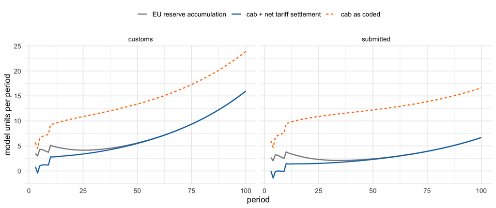

**Observed.** On the `submitted` baseline the residual is 9.9465 at t = 99, 60.3% of the current account; the net tariff settlement is -9.9465, and the two agree to 2.3 × 10⁻⁵ in every period and both regions (the maximum over periods printed by `R/bop_audit.R`). On the `customs` baseline the residual is smaller, 7.9308 at t = 99, and so is the settlement: they agree to 2.0 × 10⁻⁵. The residual computed from the income side (last column) is the same number, to 4 × 10⁻⁵. The EU bill market closes to 1.6 × 10⁻⁶ of the stock throughout (§2).

**The verdict, stated as the gate asked.** Leak, with the line named. The stocks and flows of the model are consistent — the EU’s true national net lending, 6.5366 at t = 99, equals its reserve accumulation, 6.5374, plus private capital flows of -0.00085. What does not close is the **reported** current account, which omits the net tariff settlement at `:781–802`.

### 5. The fix, and its verification

**The change** (commit `865749e`, `model/MVP_model_2026.R:804–813`, with `model/flash_MVP_model_2026.R` regenerated by `tools/build_flash_model.py`): after the dividend block, the current account gains

```r
sim[z.lab('cab'), i] <- sim[z.lab('cab'), i] +
  sim[z.lab('tar_rev'), i] - sim[rev(z.lab('xr')), i] * sim[rev(z.lab('tar_rev')), i]
```

This keeps the incidence convention the model already has in `yn` — tariffs borne by exporters — and records the payments it implies. `cab` is read only by `nafa` (`:828`), and `nafa` by nothing, so no equation of the model’s dynamics depends on the change.

**The verification** (`Rscript R/bop_fix_check.R 0` and `… 13`, run 2026-09-11, flash model, outputs in the session scratch directory — ⚠️ not in the repository, reproduce with those commands):

| Check | Baseline | Scenario 13 |
| --- | --- | --- |
| new `cab` = old `cab` + net tariff settlement, max \|diff\| | 4.2 × 10⁻⁷ | 4.3 × 10⁻⁷ |
| EU `cab` at t = 99, old → new | 16.4831 → 6.5366 | 16.8259 → 6.8600 |
| `R/bop_audit.R` verdict on the fixed baseline | CONSISTENT in every period, both regions | — |
| periods stopping at a different Gauss–Seidel sweep | 14 of 99 | (not tabulated) |
| other rows `identical()` | FALSE | FALSE |
| largest relative difference, any other row | 1.46 × 10⁻⁴, `Z1_b_cb` at t = 29 | — |
| relative difference at t = 99, value added / deficits / debt / emissions / reserves | 10⁻¹² to 10⁻⁸ | — |

**Why the other rows are not bit-identical, and why that is not a defect of the fix.** The stopping rule tests `cab` along with everything else (see Background). The corrected `cab` is smaller, so its relative iterate changes are larger, and in 14 periods a sweep more or fewer is taken. The largest relative difference falls on `Z1_b_cb` at t = 29, the period after it crosses zero (absolute difference 5.6 × 10⁻⁶ on a value of −0.039); 650 of 670,900 cells move by more than 10⁻⁷ relative, and the headline aggregates by at most 10⁻⁸. These are differences between two solutions that each meet the solver’s own tolerance.

### 6. What it does to Table 3

EU current account at t = 90 (Table 3's horizon), percentage and level deviation from baseline, as coded and with the net tariff settlement added. Correction applied post hoc to the cached runs, which is valid because cab feeds no other variable. Sc2 and Sc13 are the two current-account entries printed in Table 3.

| Arm | Scenario | Baseline cab, coded → corrected | Deviation, % coded | Deviation, % corrected | Level deviation, coded | Level deviation, corrected |
| --- | --- | --- | --- | --- | --- | --- |
| submitted | Sc2 | 15.34 → 5.39 | +1.01 | +2.71 | 0.1552 | 0.1458 |
| submitted | Sc5 | 15.34 → 5.39 | +2.88 | +7.72 | 0.4411 | 0.4158 |
| submitted | Sc10 | 15.34 → 5.39 | +1.44 | +3.89 | 0.2211 | 0.2097 |
| submitted | Sc13 | 15.34 → 5.39 | +1.81 | +4.77 | 0.2768 | 0.2569 |
| submitted | Sc14 | 15.34 → 5.39 | +1.08 | +2.90 | 0.1658 | 0.1563 |
| submitted | Sc1 | 15.34 → 5.39 | -0.71 | -1.92 | -0.1083 | -0.1035 |
| submitted | Sc9 | 15.34 → 5.39 | -0.55 | -1.50 | -0.0851 | -0.0806 |
| customs | Sc2 | 20.83 → 12.90 | +0.76 | +1.17 | 0.1592 | 0.1512 |
| customs | Sc5 | 20.83 → 12.90 | +2.15 | +3.31 | 0.4486 | 0.4274 |
| customs | Sc10 | 20.83 → 12.90 | +1.07 | +1.64 | 0.2239 | 0.2112 |
| customs | Sc13 | 20.83 → 12.90 | +1.35 | +2.06 | 0.2818 | 0.2650 |
| customs | Sc14 | 20.83 → 12.90 | +0.81 | +1.23 | 0.1684 | 0.1581 |
| customs | Sc1 | 20.83 → 12.90 | -0.53 | -0.82 | -0.1101 | -0.1061 |
| customs | Sc9 | 20.83 → 12.90 | -0.41 | -0.64 | -0.0860 | -0.0820 |

## What changed, and why the earlier accounts were wrong

**1. The instability is not “one unstable mode per region”.** *Previous claim* (`log/report/2026-09-09-transition-matrix-spectrum.qmd`, `log/session_20260909.md` §12–13): the model “has exactly one unstable mode per region, and it is the debt root”; there is no fiscal reaction function and “that is its only instability”; adding one “is the single change that would move ρ(M) below 1”, and “the *only* change that would”. *Evidence:* the eigenvectors (§1–2). The $1 + r_b^{Z2}$ eigenvector is a cross-border mode involving both regions’ bills and the EU central bank’s balance sheet; the $1 + r_b^{Z1}$ eigenvector lies entirely off the bill-market identity. Both budgets are balanced to within 0.25 once the reserve-interest flow is removed. *Corrected claim:* there is **one** economic unstable mode, and it is the unrecycled official-sector circuit RoW treasury → EU central bank → EU treasury. The second root is an accounting-residue direction. The absence of a fiscal rule is one reason nothing damps the circuit, not the only one: the circuit also runs through a fixed-rate closure with an unlimited residual buyer and a portfolio block with no rate response (§ “What it means”). *Consequence:* the supplement’s Appendix 5 (`qmd/supplementary_material.qmd`), which states the spectrum and its mechanism, should be revised to this description.

**2. The “unlocated 60%” of the EU current account is located.** *Previous claim* (`log/NEXT_SESSION.md` item 1): the EU runs `cab` = +16.483 at t = 99 against a net foreign asset change of −0.001; reserves absorb about 40%; about 60% is unlocated, and whether the model’s external accounts close was unknown. *Evidence:* §4. *Corrected claim:* the model’s stocks close; the reported current account omitted the net tariff settlement, which is the whole residual. *Consequence:* the gate resolves to “leak, line named” with a one-term fix that changes no dynamics; hand-off item 4 (imposing the portfolio matrix Λ), which was gated on this, is unblocked on the fixed branch.

**3. A correction to a claim made while doing this work.** *Previous claim* (this session’s conversation, before the derivation): the audit corrects the tax-wedge report’s statement that the model’s tariff inconsistency is “numerically small”. *Evidence:* that report (`log/report/2026-09-09-tax-wedge-stage.qmd:425–429`) concerns the import price index at `:646`, which applies the *partner’s* tariff rate to import prices. The derivation in §4 shows the import price cancels out of the balance-of-payments identity; the leak comes from `yn` at `:223`, a different line. *Corrected claim:* the tax-wedge report’s statement about `:646` is untouched by this audit and remains unmeasured. *Consequence:* the import-price convention is still an open question for the model’s authors, separate from the fix here.

## What it means

*Interpretation, resting on the measurements above.*

### The macro regime in economic terms

The baseline is a stationary economy in which both governments already pay the $r > g$ price: a primary surplus of about 2.3% of value added, transferred through the banks to bondholders. That part of the fiscal system is stable, because the interest it pays comes back as taxable, partly spent private income.

Layered on it is an external arrangement with no adjustment mechanism anywhere. The RoW runs a current-account deficit, financed without limit by the EU central bank at the RoW bill rate. The interest on that financing is itself borrowed from the same central bank and passed to the EU treasury, which uses it to retire debt. The EU’s consolidated public sector — treasury plus central bank — owes its private sector a constant amount (1,327.1 at t = 50, 1,333.4 at t = 99) while its claims on the RoW grow at the RoW bill rate. In political-economy terms, the periphery’s public debt to the core’s central bank grows by compound interest, and neither private sector’s income, spending or wealth is touched by it. So nothing in the model is forced to contract, and nothing stops the debt compounding. The instability is the absence of any agent whose behaviour depends on the circuit.

### It is tied to the portfolio block, and to two other closures

The residual buyer of RoW bills is the EU central bank because three closures coincide: private bill demand is a fixed share of stationary wealth with every rate coefficient zero (the Λ block, `:521–565`); the exchange rate is fixed with the EU central bank as residual buyer (`:853–866`); and government spending is exogenous. Change any one and the circuit is altered. That is why the portfolio characterisation matters here. It is also why it cannot be fixed by estimation: every interest rate is constant over the run, so the Λ rate coefficients are unidentified (the earlier design had rank 2) and would have to be imposed from theory — hand-off item 4.

The tariff leak is **not** tied to Λ. It is a trade-and-income accounting convention.

### Closure choices: who adjusts

*Each row’s effect on the root is inferred from the eigenvector structure in §1 — which flows the mode runs through — and has not been simulated.* ⚠️ UNCERTAIN for all magnitudes.

Five closure changes that act on the unstable circuit, by who bears the adjustment.

[output not shown]

## Limits and what is not established

- **The fix records the incidence the model already assumes; it does not choose it.** An alternative closes the identity equally well: change `yn` at `:223` to deduct the region’s *own* tariff revenue, so that tariffs fall on importers and no cross-border tariff payment arises. That alternative changes domestic incomes and therefore every variable, and has not been run. Which incidence is right is a modelling decision for the authors.
- **The fixed runs are not in the repository.** The verification table quotes `R/bop_fix_check.R`’s output. The corrected Table 3 figures are computed post hoc from the cached runs, which the check shows agrees with the in-model fix to 4 × 10⁻⁷ in `cab` levels.
- **The eigenvector reading is at one base point on the unshocked baseline** (t = 50). It was not re-measured under a shock or on the fixed model, although the fix cannot change `M` beyond solver noise, because nothing reads `cab`.
- **The closure options are not simulated.** The shortfall and growth figures in the last table are static arithmetic on t = 99 flows and ignore feedback, above all the multiplier effect of a fiscal rule on tax revenue.
- **The regime clustering was not re-run.** `cab` was already excluded from the divergence space (`qmd/cross_border_analysis.qmd:505`), but it enters the joint (Z1, Z2) profiles through the External block, whose levels this correction changes. ⚠️ UNCERTAIN whether the three-regime partition moves.

## Where this leaves things

Options, not a sequence:

1. **Merge `bop-audit` into `main`**, or keep it as a branch until the tariff-incidence decision above is taken. Either way the `cab` and `nafa` columns of every cached run are now known to be misstated by the net tariff settlement, and every figure or table built on them should be read with that in mind.
2. **Correct the two current-account entries in Table 3 and the prose at `:705`**, jointly with the tariff-base decision (hand-off item 3), since the two interact. Consider reporting the current account as a level or as a share of value added rather than as a percentage of its own baseline, which at 5.4 is small enough to magnify every deviation.
3. **Revise Appendix 5 of the supplement** to describe the instability as the unrecycled official-sector circuit, and state the stationary baseline and the compounding component of the fiscal deviations.
4. **Proceed to Λ (hand-off item 4)** on the fixed branch. Its gate has resolved.
5. **Decide whether a closure change belongs in this revision or the next paper.** The cheapest targeted change is the zero-remunerated reserve claim; the substantive one is a growth closure, which replaces the stationary baseline and every number built on it.

`ai_context/` records nothing about the balance of payments, the model’s dynamics or this correction. `/update-project-context` is warranted.

**Sources:** `model/MVP_model_2026.R` (on `bop-audit`) · `model/flash_MVP_model_2026.R` · `tools/build_flash_model.py` · `model/run_model_2026.R` · `R/bop_audit.R` · `R/bop_fix_check.R` · `R/table3_arm_diff.R` · `output/scenarios/full_mrio_baseline_2026.RDS` · `output/scenarios/shock_runs/shock_{5,13}_run.RDS` · `output/scenarios/arms/{submitted,customs}/runs/` · `data/transition_matrix_t50.rds` · `log/NEXT_SESSION.md` · `log/session_20260909.md`, `log/session_20260910.md` · `log/report/2026-09-09-transition-matrix-spectrum.qmd` · `log/report/2026-09-09-tax-wedge-stage.qmd` · `qmd/paper_revision_2026-11-13.qmd` · `qmd/supplementary_material.qmd` · commits `865749e`, `b44cf42` · Godley, W. and Lavoie, M. (2007), *Monetary Economics*, ch. 12 (the fixed-exchange-rate closure the model follows).